# Integrated Douyin and KuGou EDA

Music Platform Data Project

2026-11-17

# 1. Data Quality and Scope

Data quality is checked before any exploratory figure is produced. The integrated dataset covers 14 November 2024 to 13 November 2026. The daily panel contains 117530 song-date rows and 2568 title-coding rows. The observation layer contains 101427 platform records: 28427 Douyin records and 73000 KuGou records.

The integrated analysis keeps original platform records and uses title-based matching only as an exploratory cross-platform key. Missing native metrics mean that a song was not observed on that platform that day; they are not replaced with zero. Duplicate platform-date-track keys are checked before aggregation, and daily visibility is reduced to one song-date record using `any(observed == 1)`.

| platform | records | dates | tracks | missing_title | duplicate_track_date |
| --- | --- | --- | --- | --- | --- |
| douyin | 28427 | 729 | 526 | 0 | 0 |
| kugou | 73000 | 730 | 2635 | 0 | 0 |

# 2. Platform-Specific and Shared Song Candidates

The first comparison shows how many song candidates are unique to each platform and how many are shared by Douyin and KuGou. Shared songs are counted by `cross_platform_song_id`; they are not treated as confirmed identical recordings because the matching key is normalized title only.

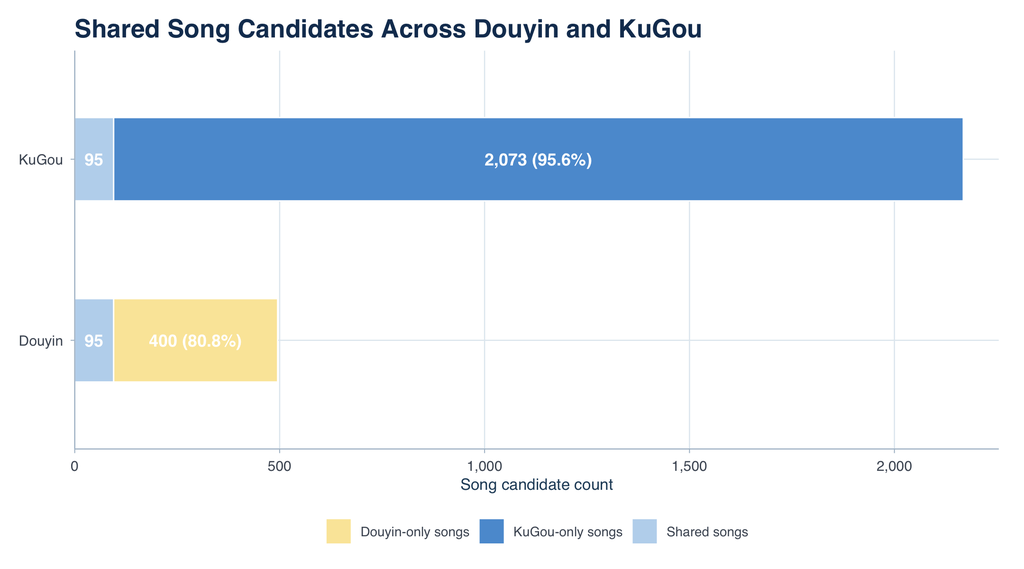

# 3. Monthly Observation Pattern

This section first describes the overall monthly pattern of shared songs. `Douyin` and `KuGou` count distinct shared-song candidates observed at least once on the corresponding platform within each month. `Both` counts distinct candidates observed on both platforms on the same day within that month; it is therefore a same-day overlap count rather than the sum of daily records.

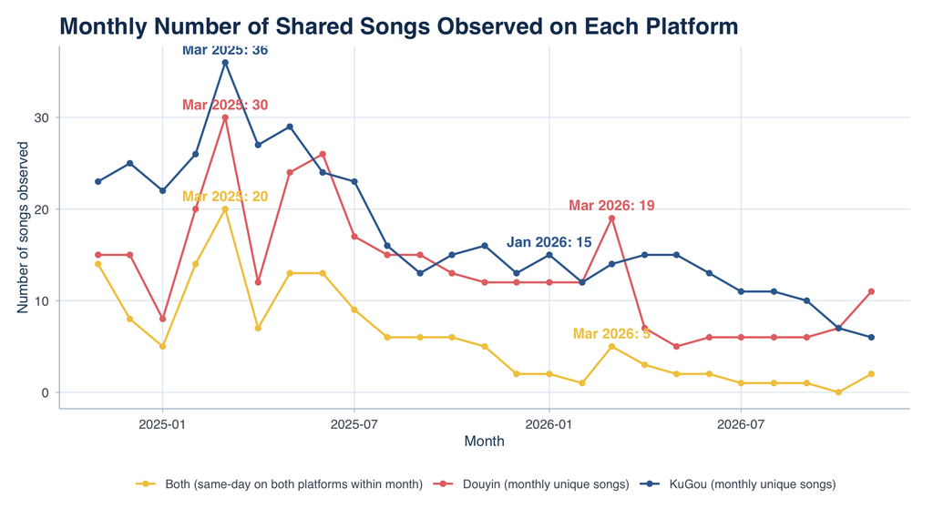

# 4. Temporal Overlap Distribution

For each shared song, we compare the number of days on which it appeared on both platforms with the total number of days on which it appeared on either platform. Values near 0 mean that the song was usually observed on different days, while values near 1 mean that its observation days largely coincided. This provides a direct view of whether songs shared by the two platforms were actually observed at the same time.

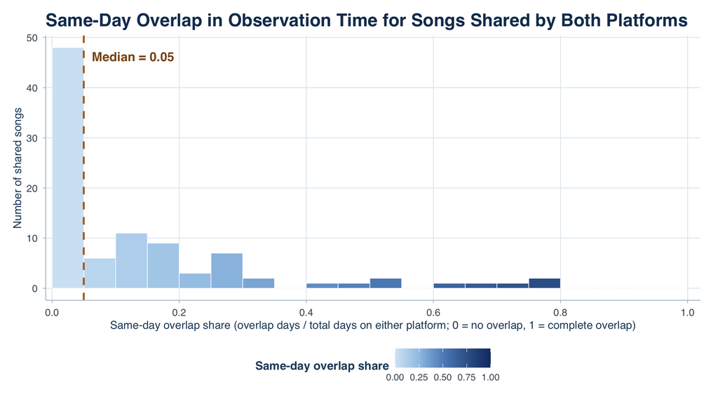

# 5. First-Observed Platform Timing

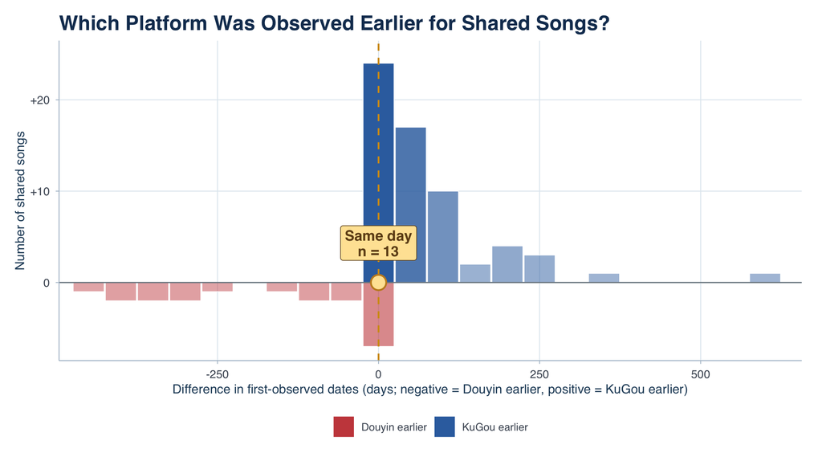

# 6. Shared Songs: Visibility and Rank Performance

For the shared title candidates, each point represents one candidate. Repeated source rows do not receive extra weight. Circle size uses a descriptive top-heavy combined rank score: rank 1 receives the highest score and lower ranks decrease exponentially. The score is calculated separately for Douyin and KuGou and then combined geometrically; colour shows the share of observation days with same-day presence on both platforms.

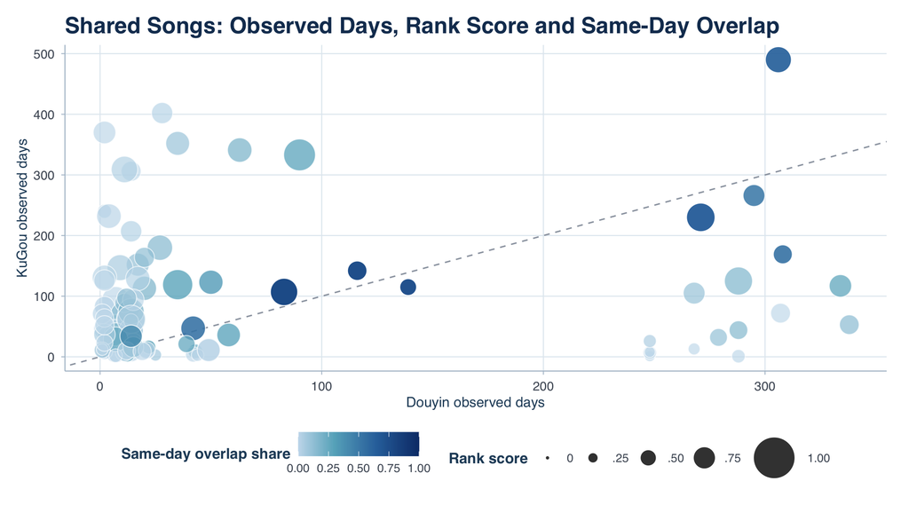

# 7. Genre and Mood: Platform Preference and First-Observed Timing

Genre and mood are analysed together with two complementary views: platform composition and first-observed timing. The left panel compares the share of labelled songs on Douyin and KuGou; the right panel shows whether each platform was observed earlier within each category. Because labels can be multi-valued, category shares are descriptive label shares rather than mutually exclusive song proportions.

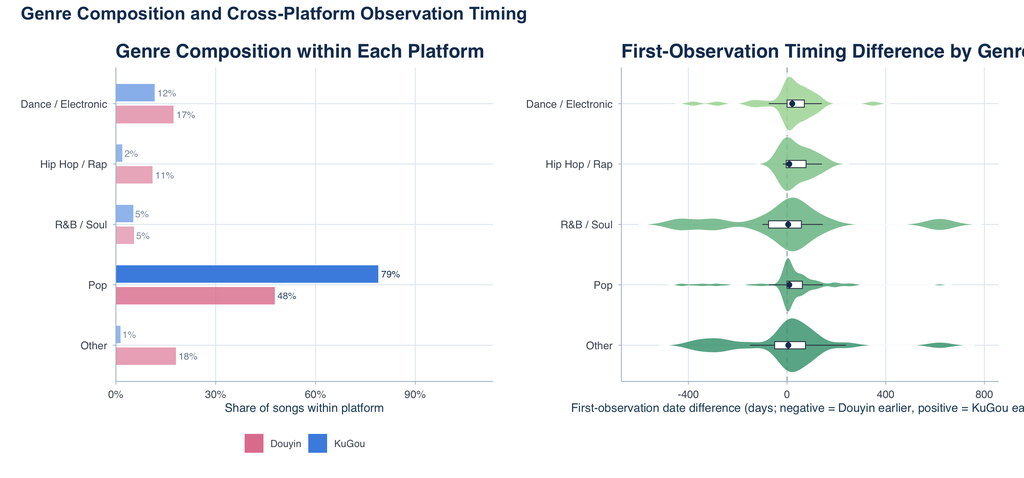

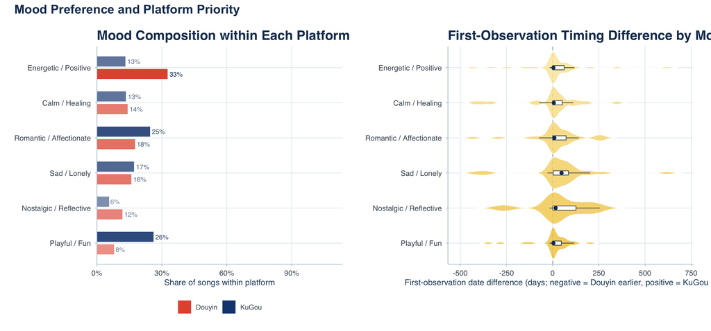

# 8. Main Findings and Limits

- The available candidate sets are highly asymmetric: KuGou contributes many more title candidates, while only a smaller subset is shared by title matching.
- Shared title candidates are not necessarily the same recording; version, artist and recording identity are not fully validated.
- Shared candidates show different observed-day patterns across platforms, and temporal overlap is generally limited.
- Mood comparisons are descriptive because labels may be multi-valued and platform taxonomies differ.
- Platform-native metrics remain separate. The EDA supports coverage, visibility, temporal overlap and composition analysis, but not a unified popularity score or causal conclusion.

The next step can use the shared candidate ID for exploratory interaction analysis with Douyin, while preserving `platform_record_id` and the original platform rows for version-level checks.

# 9. Reproducibility

This report reads `data/processed/platform_song_daily_panel.csv`, `data/processed/platform_song_coding.csv`, and `data/audit/platform_combined_overlap_observations.csv`. Render it from the project root with:

```r
rmarkdown::render("analysis/platform_combined_eda.Rmd")
```